# HackUIowa2022: Engie Historical Dataset

John Piaszynski

2022-10-16

## Total Usage

#### Purchased vs Generated

The following chart shows the total proportion of electricity generated across both campuses. The proportion is relatively low for the second half of 2021, but picks up markedly around January 2022.

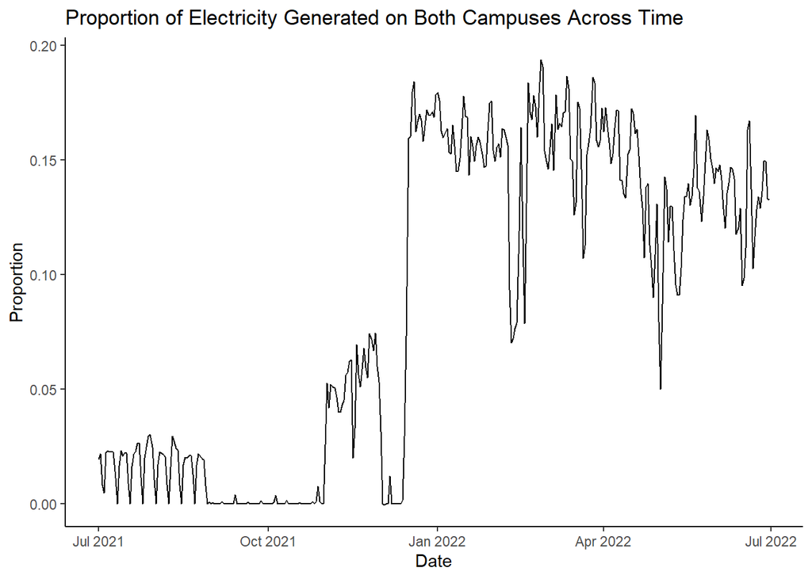

#### Campus Comparison

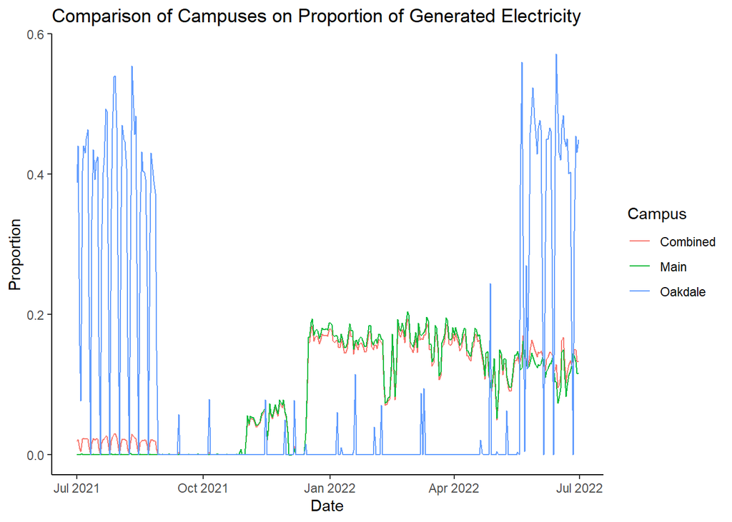

#### Purchased Energy and Emissions

The amount of purchased energy is not a strong predictor of overall emissions, indicating that little is gained or lost by shifting the ratio of purchased to generated electricity. Correlation between amount purchased and overall greenhouse gas emissions is 0.15. (Note that pollutant emissions are scaled down by a factor of 500).

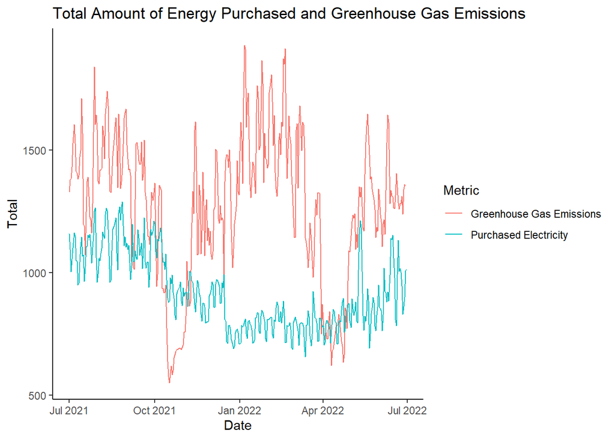

Same comparison, using amount of generated electricity. (Pollutant emissions scaled down by factor of 5000).

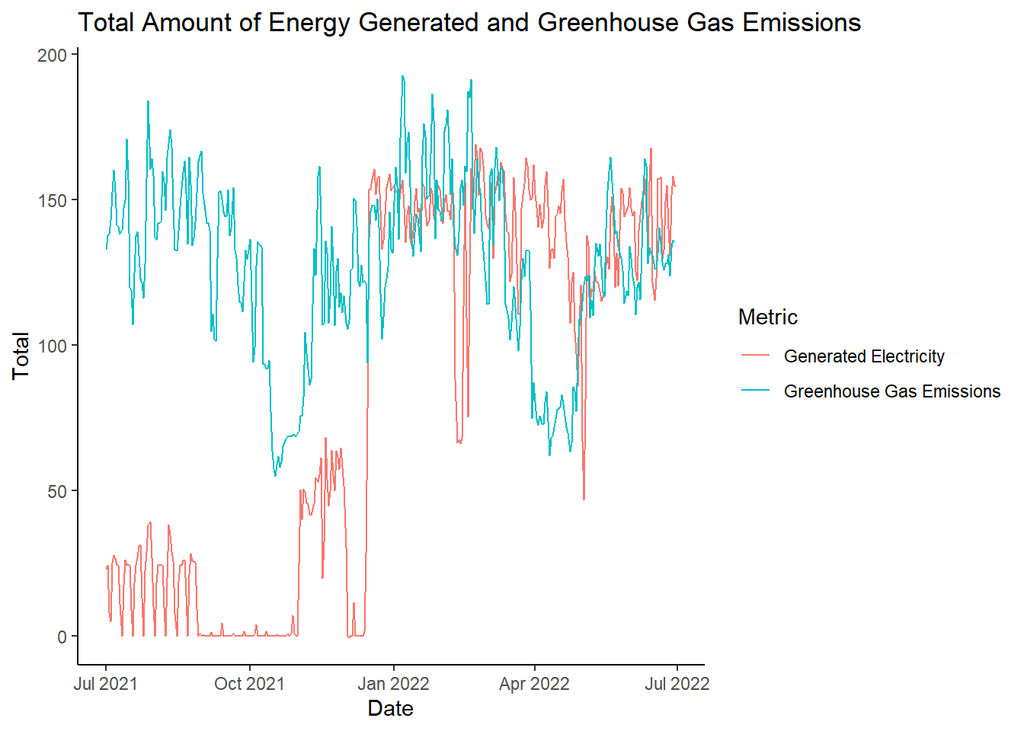

## Fuel Source

#### Breakdown of Fuel Source

Proportion of energy produced by each fuel source across time. In the warmer months, load is shared roughly equally, but during the winter months, natural gas becomes the dominant fuel source. Shown here are a sample of values across time.

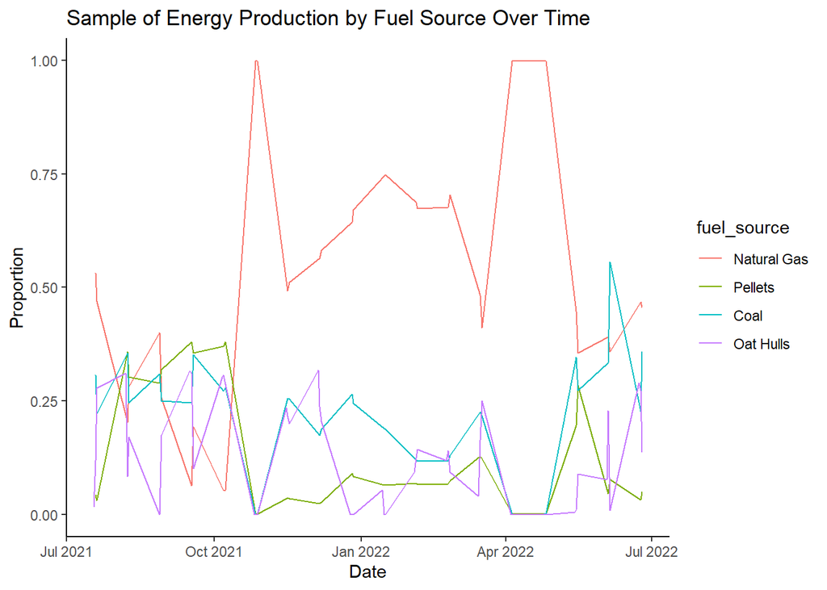

#### Fuel Source and Greenhouse Gas Emissions

Proportion of greenhouse gas emissions by fuel source. Natural gas is still responsible for most of the emissions during the winter months (as would be expected given its higher proportion), but during the warmer months, other sources are clearly worse polluters, despite their roughly equal use.

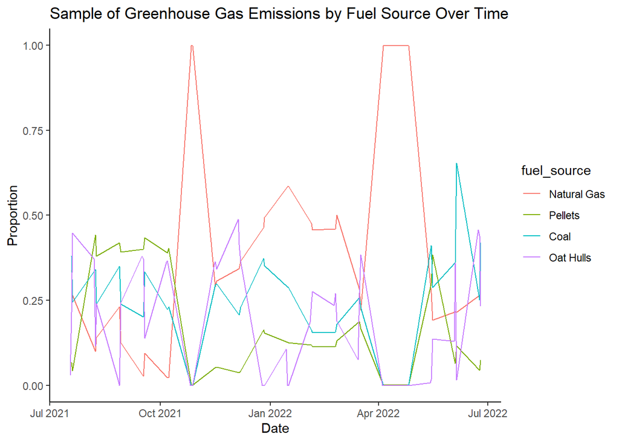

#### Disproportionate Pollutants

Here the proportions of the total volume of emissions are compared to the proportion of pollutants released by each fuel source. Natural gas is a disproportionately clean source compared to the others, having a lower proportion of greenhouse gas emissions relative to total volume of emissions produced.

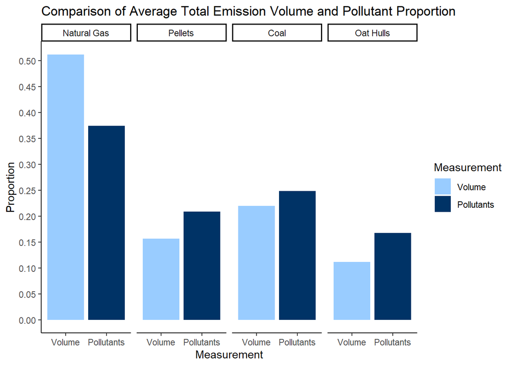

These relationships are relatively consistent across time, though the magnitudes fluctuate. The following are a snapshot of different days during the year.

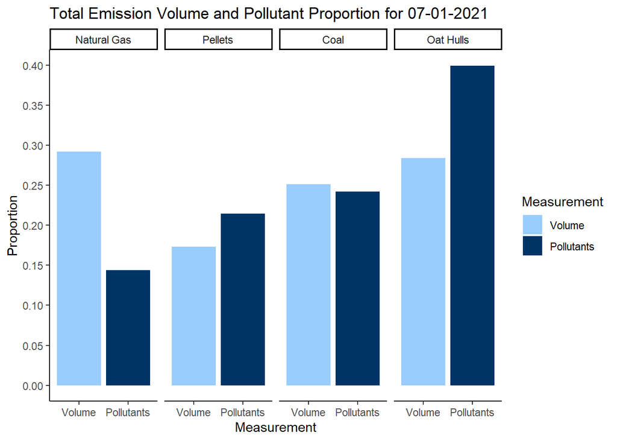

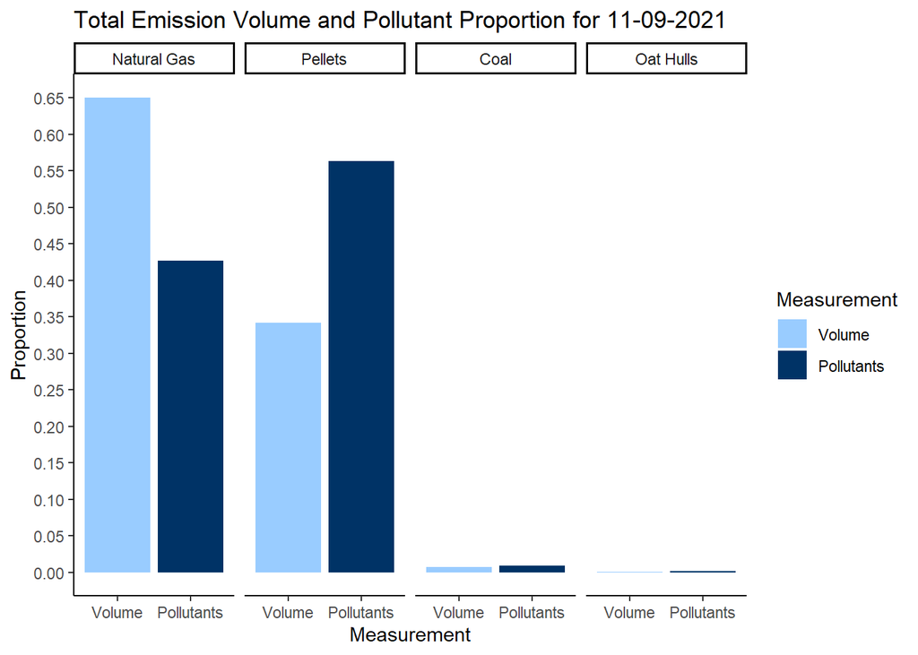

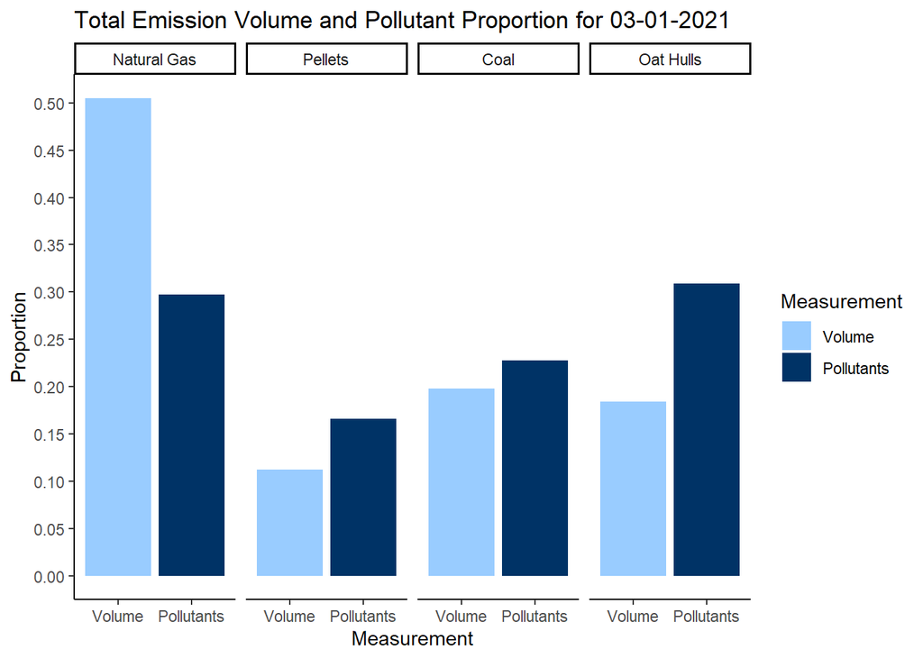

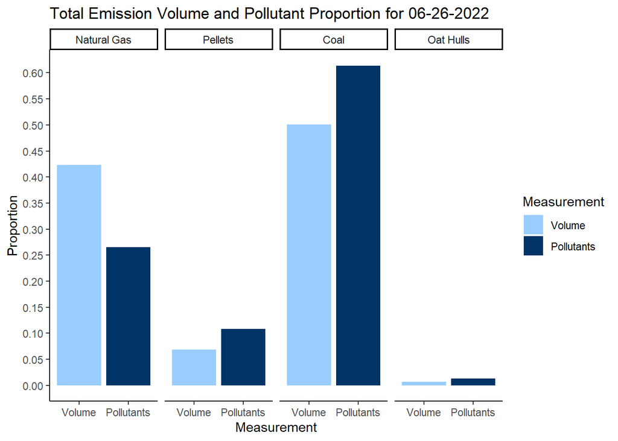

## Correlation between Fuel Source and Emissions

Association between total amount of natural gas used alongside total greenhouse gas emissions. Greater use of natural gas is associated with a reduction in greenhouse gas emissions, with a correlation of -0.21. Pollutants scaled down by a factor of 200.

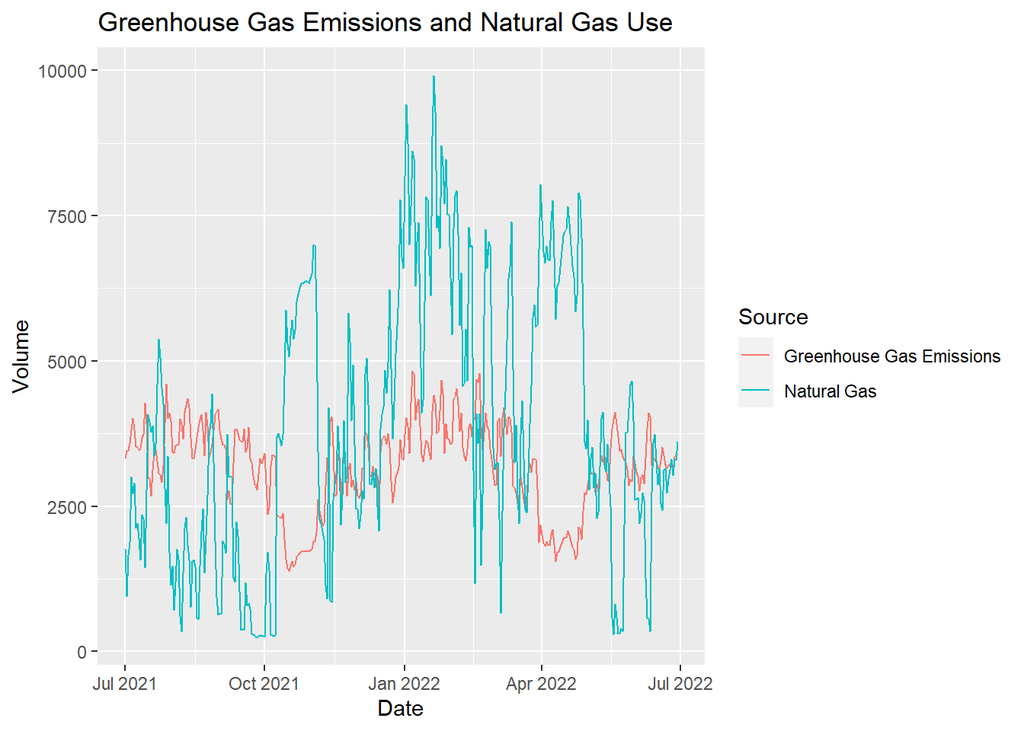

Association between Pellet use and greenhouse gas emissions. The correlation between the two is 0.5933752. Pollutants scaled down by 250.

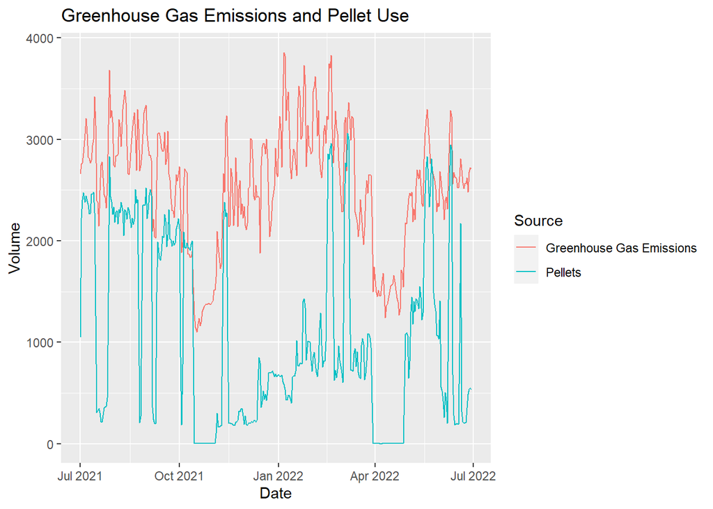

Coal use and greenhouse gas emissions. Correlation is 0.5714405. Pollutants scaled down by 250.

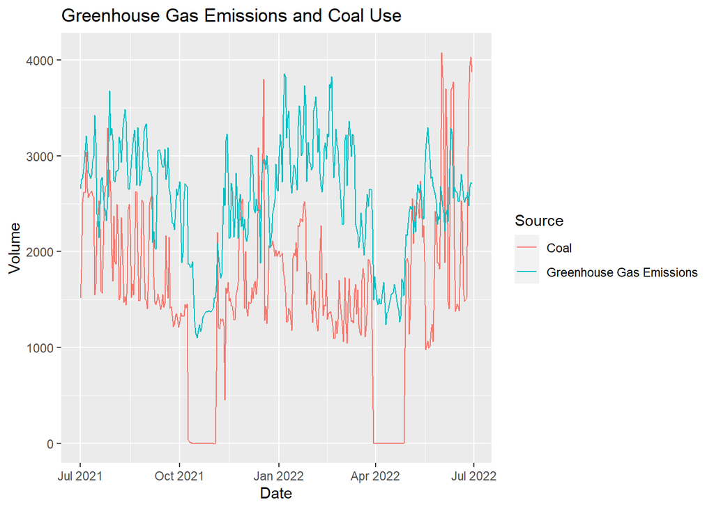

Oat hull use and greenhouse gas emissions. Correlation is 0.438179. Pollutants scaled down by a factor of 300.

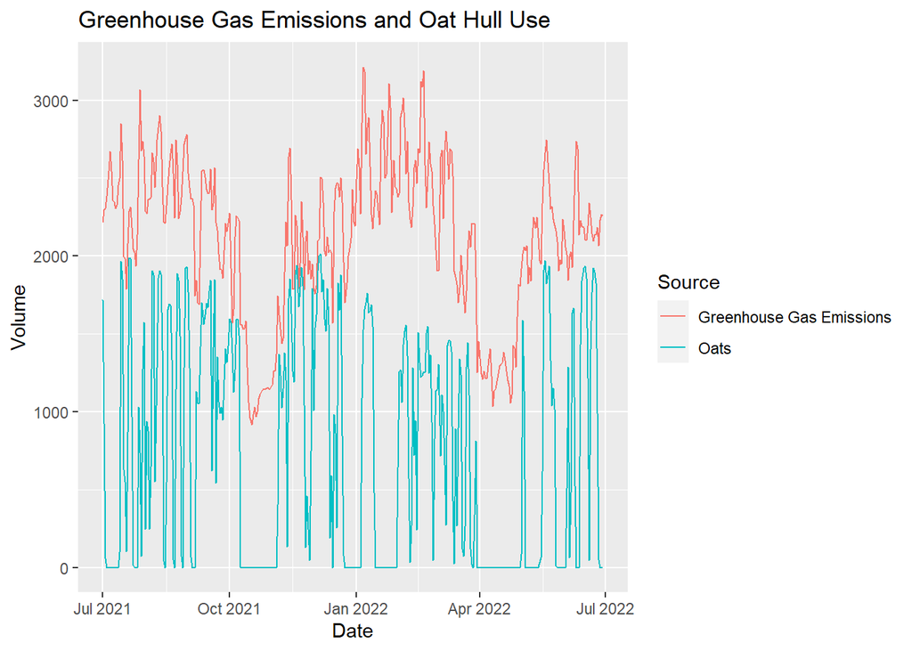